# Examen Modulo 3

Lucía Pena Pais

07/03/2021

## Ejercicio 1

**Instale la librería vars y utilice la base de datos Canada, que incluye las variables prod, e, U, rw. Buscando la ayuda sobre el fichero, indique que significa y como están medidas las cuatro variables.**

**Tenga presente que los datos están en formato de series temporales (ts). Si no desea trabajar en este formato, conviértalo a un data frame. ¿Qué periodo temporal cubren estos datos?**

**Realice un análisis descriptivo de las variables.**

```r
suppressWarnings(suppressPackageStartupMessages(library(vars)))
data(Canada)
str(Canada)
```

```
##  Time-Series [1:84, 1:4] from 1980 to 2001: 930 930 930 931 933 ...
##  - attr(*, "dimnames")=List of 2
##   ..$ : NULL
##   ..$ : chr [1:4] "e" "prod" "rw" "U"
```

```r
?Canada
```

Este dataset contiene datos Macroeconómicos de Canadá desde el 1er trimestre del año 1980 hasta el 4º trimestre del año 2000.

- prod: es la medida de la productividad laboral -> 100*(ln(PIB nominal/IPC)-ln(empleo civil en 1000 personas))
- e: indica el empleo -> 100*ln(empleo civil en 1000 personas)
- U: es el ratio de desempleo (% de desempleo)
- rw: salario real -> 100* ln(100*salario real)

```r
Canada <- as.data.frame(Canada)
str(Canada)
```

```
## 'data.frame':    84 obs. of  4 variables:
##  $ e   : num  930 930 930 931 933 ...
##  $ prod: num  405 405 404 404 405 ...
##  $ rw  : num  386 388 391 394 397 ...
##  $ U   : num  7.53 7.7 7.47 7.27 7.37 ...
```

```r
summary(Canada)
```

```
##        e              prod             rw              U
##  Min.   :928.6   Min.   :401.3   Min.   :386.1   Min.   : 6.700
##  1st Qu.:935.4   1st Qu.:404.8   1st Qu.:423.9   1st Qu.: 7.782
##  Median :946.0   Median :406.5   Median :444.4   Median : 9.450
##  Mean   :944.3   Mean   :407.8   Mean   :440.8   Mean   : 9.321
##  3rd Qu.:950.0   3rd Qu.:410.7   3rd Qu.:461.1   3rd Qu.:10.607
##  Max.   :961.8   Max.   :418.0   Max.   :470.0   Max.   :12.770
```

Vemos que los valores de las todas las variables están bastante concentrados alrededor de la media, ya que no tienen valores minimos y máximos muy alejados. Esto indicaría que la varianza no es muy alta.

```r
library(skimr)
skim(Canada)
```

Data summary

| Name | Canada |
| --- | --- |
| Number of rows | 84 |
| Number of columns | 4 |
| _______________________ |  |
| Column type frequency: |  |
| numeric | 4 |
| ________________________ |  |
| Group variables | None |

**Variable type: numeric**

| skim_variable | n_missing | complete_rate | mean | sd | p0 | p25 | p50 | p75 | p100 | hist |
| --- | --- | --- | --- | --- | --- | --- | --- | --- | --- | --- |
| e | 0 | 1 | 944.26 | 9.16 | 928.56 | 935.35 | 945.95 | 950.03 | 961.77 | ▆▂▇▅▃ |
| prod | 0 | 1 | 407.82 | 4.22 | 401.31 | 404.75 | 406.46 | 410.70 | 418.00 | ▆▇▅▃▂ |
| rw | 0 | 1 | 440.75 | 23.27 | 386.14 | 423.90 | 444.44 | 461.10 | 470.01 | ▂▂▅▂▇ |
| U | 0 | 1 | 9.32 | 1.61 | 6.70 | 7.78 | 9.45 | 10.61 | 12.77 | ▇▃▇▆▂ |

Vemos que la distribución estándar es más alta en el salario que en resto de variables. Viendo los histográmas no parece que sigan una distribución normal, pero habría que revisarlo en profundidad realizando los tests correspondiente.

## Ejercicio 2

**Estime un modelo MCO que relacione la productividad con los salarios. Responda:**

```r
mod.simple <- lm(prod~rw, data = Canada)
summary(mod.simple)
```

```
##
## Call:
## lm(formula = prod ~ rw, data = Canada)
##
## Residuals:
##     Min      1Q  Median      3Q     Max
## -6.0050 -1.4443  0.1717  1.7235  6.2171
##
## Coefficients:
##              Estimate Std. Error t value Pr(>|t|)
## (Intercept) 348.09777    5.86302   59.37   <2e-16 ***
## rw            0.13550    0.01328   10.20    3e-16 ***
## ---
## Signif. codes:  0 '***' 0.001 '**' 0.01 '*' 0.05 '.' 0.1 ' ' 1
##
## Residual standard error: 2.816 on 82 degrees of freedom
## Multiple R-squared:  0.5593, Adjusted R-squared:  0.5539
## F-statistic:   104 on 1 and 82 DF,  p-value: 3.003e-16
```

**1) ¿Son significativos los parámetros a un α = 0,05? Justifique su respuesta.**

Sí, son significativos a un α = 0,05, ya que podemos ver que los p-valores de ambos, son menores que 0,05. El intercepto es el parámetro de la constante ($\beta_0$).

**2) Obtenga un intervalo de confianza para la pendiente para un nivel de significación del 90%.**

```r
#Valor crítico
v.critico <- qt(0.95, mod.simple$df.residual)
v.critico
```

```
## [1] 1.663649
```

```r
#Intervalo de confianza al 90% para beta1
c(summary(mod.simple)$coefficients[2,1]-v.critico*summary(mod.simple)$coefficients[2,2],summary(mod.simple)$coefficients[2,1]+v.critico*summary(mod.simple)$coefficients[2,2])
```

```
## [1] 0.1134032 0.1576032
```

El intervalo de confianza para $\beta_1$ al 90% es de 0.1134 a 0.1576. También se podría hacer de la siguiente forma:

```r
confint.lm(mod.simple,"rw",level = 0.90)
```

```
##          5 %      95 %
## rw 0.1134032 0.1576032
```

**3) Evalúe la normalidad de los residuos a través de un histograma, un qq‐plot y un test de normalidad. ¿Son normales los residuos? Justifique su respuesta.**

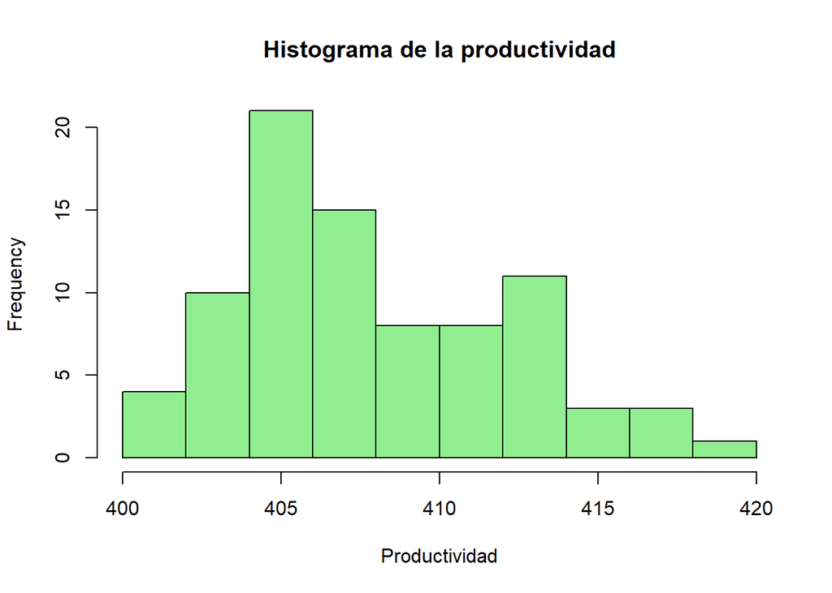

```r
#Histograma
hist(Canada$prod, col = "lightgreen", main = "Histograma de la productividad", xlab = "Productividad")
```

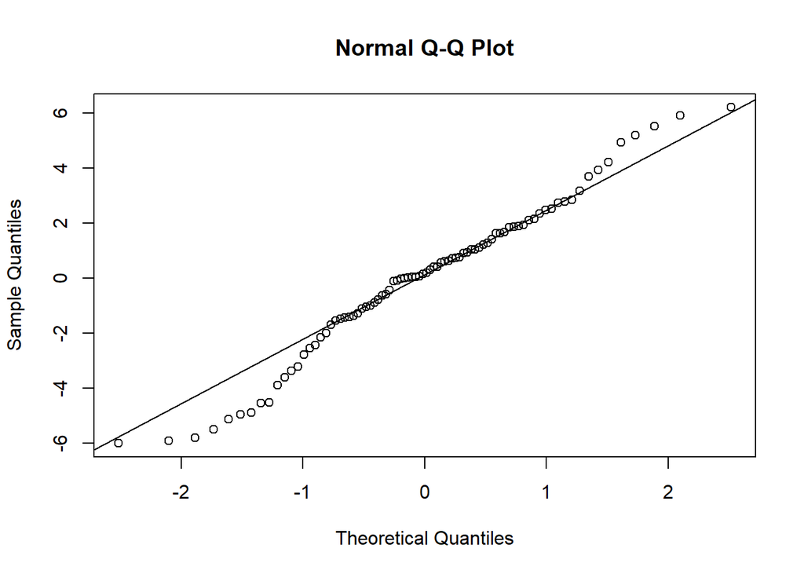

```r
#Gráfico Q-Q Plot
qqnorm(mod.simple$residuals)
qqline(mod.simple$residuals)
```

```r
#Test de normalidad Jarque-Bera
suppressWarnings(suppressPackageStartupMessages(library(tseries)))
jarque.bera.test(mod.simple$residuals)
```

```
##
##  Jarque Bera Test
##
## data:  mod.simple$residuals
## X-squared = 0.5604, df = 2, p-value = 0.7556
```

```r
#Test de normalidad Lilliefors
suppressWarnings(suppressPackageStartupMessages(library(nortest)))
lillie.test(mod.simple$residuals)
```

```
##
##  Lilliefors (Kolmogorov-Smirnov) normality test
##
## data:  mod.simple$residuals
## D = 0.091978, p-value = 0.07599
```

```r
#Test de heterocedasticidad White
suppressWarnings(suppressPackageStartupMessages(library(tseries)
))
x <- matrix(Canada$rw, ncol=1)
y <- matrix(Canada$prod, ncol=1)
white.test(x,y)
```

```
##
##  White Neural Network Test
##
## data:  x and y
## X-squared = 34.95, df = 2, p-value = 2.575e-08
```

Los test de normalidad tienen un p-valor > 0.05, por lo que aceptaríamos la hipótesis de normalidad. Sin embargo, el test de heterocedasticidad, tiene un p-valor < 0.05, por lo que rechazaríamos la hipótesis nula de homocedasticidad.

Por tanto, siguiendo los resultados del qq-plot y los tests de normalidad y heterocedasticidad, concluiríamos que los residuos tienen una distribución normal heterocedástica.

**4) Siendo datos de series temporales, verifique a través del contraste de Durbin Watson si existen problemas de autocorrelación.**

```r
suppressWarnings(suppressPackageStartupMessages(library(lmtest)))
dwtest(mod.simple)
```

```
##
##  Durbin-Watson test
##
## data:  mod.simple
## DW = 0.07324, p-value < 2.2e-16
## alternative hypothesis: true autocorrelation is greater than 0
```

Dado que el p-valor es menor que 0.05, rechazamos la hipótesis nula de no autocorrelación. Por lo que, podemos decir que existe autocorrelación positiva (el estadístico es menor que 2) entre los residuos.

**5) Realice un gráfico que muestre los resultados de la regresión lineal simple. ¿Utilizaría este modelo para obtener pronósticos sobre la productividad?**

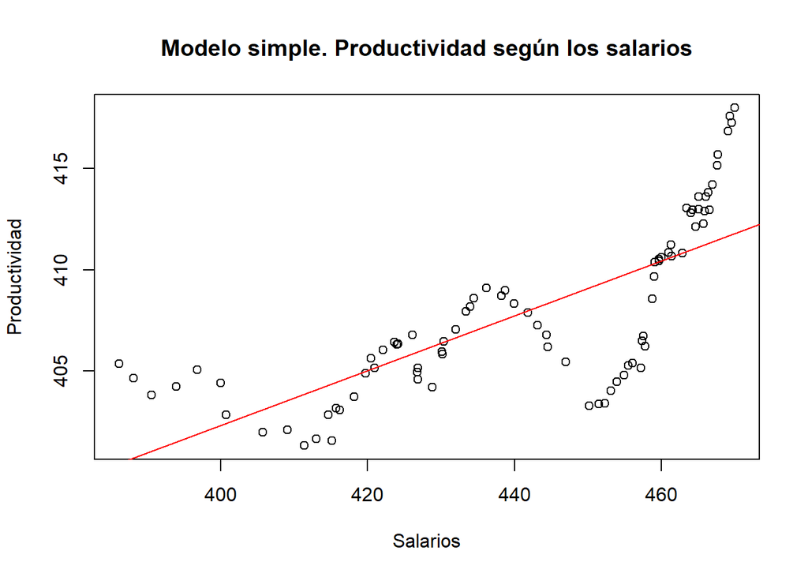

```r
plot(Canada$rw, Canada$prod, main = "Modelo simple. Productividad según los salarios", xlab = "Salarios", ylab = "Productividad")
abline(mod.simple, col = "red")
```

No utilizaría este modelo, ya que como podemos ver en el gráfico, la línea de regresión no se ajusta a los residuos y en el summary del modelo, vemos que el $R^2$ ajustado es bastante bajo (0.55%). Es decir, que el modelo explicaría un 55% de la variación de la producción. Además de la existencia de la heterocedasticidad y una fuerte autocorrelación que habría que solventar.

## Ejercicio 3

**Realice una regresión múltiple para explicar los salarios con todas las variables del data set.**

```r
mod.multiple <- lm(rw ~ ., data = Canada)
summary(mod.multiple)
```

```
##
## Call:
## lm(formula = rw ~ ., data = Canada)
##
## Residuals:
##     Min      1Q  Median      3Q     Max
## -5.1931 -1.4727  0.1015  1.3970  4.6258
##
## Coefficients:
##               Estimate Std. Error t value Pr(>|t|)
## (Intercept) -2.229e+03  2.630e+01 -84.751   <2e-16 ***
## e            2.865e+00  4.878e-02  58.732   <2e-16 ***
## prod        -2.174e-01  1.108e-01  -1.961   0.0533 .
## U            5.721e+00  1.566e-01  36.538   <2e-16 ***
## ---
## Signif. codes:  0 '***' 0.001 '**' 0.01 '*' 0.05 '.' 0.1 ' ' 1
##
## Residual standard error: 1.988 on 80 degrees of freedom
## Multiple R-squared:  0.993,  Adjusted R-squared:  0.9927
## F-statistic:  3764 on 3 and 80 DF,  p-value: < 2.2e-16
```

**1) Señale cuáles de las variables explicativas son significativas y cuales no lo son al 99% y al 95%. Justifique su respuesta.**

Las variables significativas son el empleo (e) y el ratio de desempleo (U). Ambas son significativas tanto al 99% como al 95%, ya que sus p-valores son menores que 0.01 y 0.05.

La variable producción también es ligeramete significativa, pero al 90% (p-valor < 0.1).

**2) Explique qué efecto tiene el desempleo en los salarios.**

Por cada punto de aumento de la tasa de desempleo, los salarios aumentan en 5.721 puntos, ya que el parámetro $\beta_3$ del desempleo es 5.721.

**3) ¿Considera que los residuos de este modelo son aleatorios? Justifique su respuesta.**

```r
#Test de normalidad Lilliefors
lillie.test(mod.multiple$residuals)
```

```
##
##  Lilliefors (Kolmogorov-Smirnov) normality test
##
## data:  mod.multiple$residuals
## D = 0.081949, p-value = 0.1774
```

```r
#Test de heterocedasticidad Breusch-Pagan
bptest(mod.multiple)
```

```
##
##  studentized Breusch-Pagan test
##
## data:  mod.multiple
## BP = 8.4645, df = 3, p-value = 0.03733
```

```r
#Test autocorrelación Durbin-Watson
dwtest(mod.multiple)
```

```
##
##  Durbin-Watson test
##
## data:  mod.multiple
## DW = 0.51169, p-value < 2.2e-16
## alternative hypothesis: true autocorrelation is greater than 0
```

Al realizar los tests de heterocedasticidad y autocorrelación, comprobamos que el p-valor es menor que 0.05, por lo que descartamos las hipótesis de homocedasticidad y no autocorrelación. El incumplimiento de dichas hipótesis implica la **no aleatoriedad** de los residuos.

Para que los residuos sean considerados aleatorios, deben cumplirse las siguientes hipótesis:

- Media cero
- Varianza constante
- Residuos incorrelacionados

La hipótesis de normalidad, sí se cumpliría.

**4) Presente un gráfico con los valores reales y los estimados, y evalúe los resultados obtenidos.**

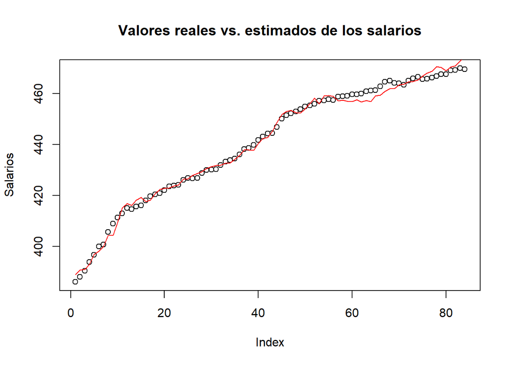

```r
plot(Canada$rw, main = "Valores reales vs. estimados de los salarios", ylab = "Salarios")
lines(mod.multiple$fitted.values, col = "red")
```

Vemos que la estimación es muy buena, ya que los valores estimados se ajustan mucho a los valores reales. Esto coincide con lo que habíamos comprobado antes en summary(), al tener un $R^2$ de 0.99. Sin embargo, habría que solventar la no aleatoriedad de los residuos.

**5) Cree usted que hay problemas de multicolinealidad entre los regresores.**

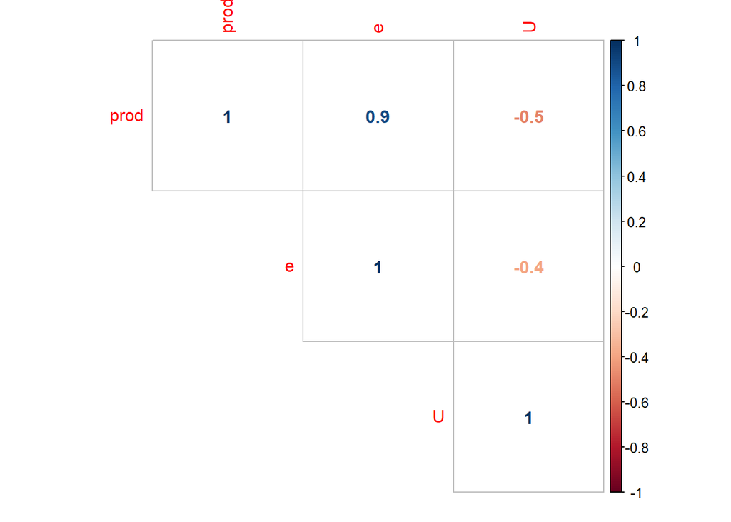

```r
suppressWarnings(suppressPackageStartupMessages(library(corrplot)))
var_num <- Canada[,c("prod", "e", "U")]
correlaciones <- round(cor(var_num),1)
corrplot(correlaciones, method = "number",type = "upper")
```

```r
suppressWarnings(suppressPackageStartupMessages(library(car)))
vif(mod.multiple)
```

```
##        e     prod        U
## 4.191146 4.586696 1.329895
```

En la matriz de correlaciones, vemos que existe una relación alta y positiva (0.9) entre las variables productividad y empleo.

Al calcular el VIF del modelo, observamos que ambas variables adquieren un valor por encima de 3. Por tanto, podemos afirmar que existe un problema de multicolinealidad entre las variables productividad y empleo.

**6) Busque de forma automática el mejor modelo para los salarios de la industria manufacturera utilizando el método forward. Presente los sumarios y gráficos de los resultados, y justifique cual es el modelo que utilizaría para la estimación de los salarios.**

```r
suppressWarnings(suppressPackageStartupMessages(library(leaps)))
regfit.fwd = regsubsets(rw~., data = Canada, method = "forward")
summary(regfit.fwd)
```

```
## Subset selection object
## Call: regsubsets.formula(rw ~ ., data = Canada, method = "forward")
## 3 Variables  (and intercept)
##      Forced in Forced out
## e        FALSE      FALSE
## prod     FALSE      FALSE
## U        FALSE      FALSE
## 1 subsets of each size up to 3
## Selection Algorithm: forward
##          e   prod U
## 1  ( 1 ) "*" " "  " "
## 2  ( 1 ) "*" " "  "*"
## 3  ( 1 ) "*" "*"  "*"
```

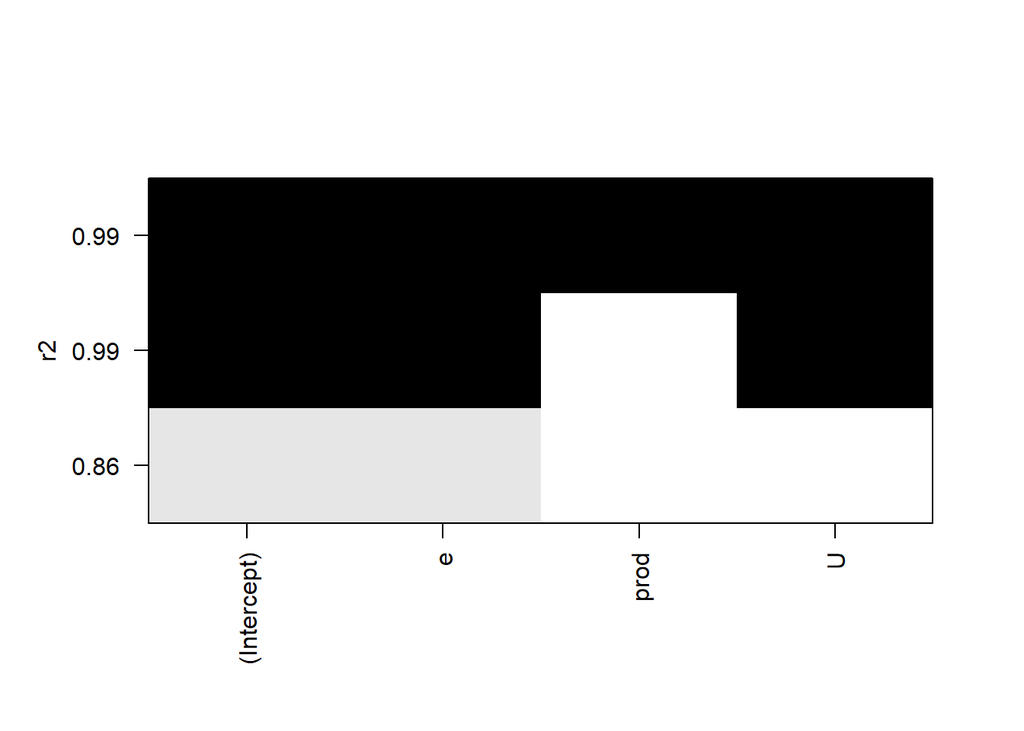

```r
plot(regfit.fwd,scale="r2")
```

El método forward nos indica que las variables más relevantes son el empleo (e) y la tasa de desempleo (U), ya que con la inclusión de esas variables se alcanza un $R^2$ de 0.99 y al incluir la variable productividad (prod) este no aumenta.

Al eliminar la variable productividad, resolveríamos los problemas de multicolinealidad del modelo.

```r
mod.multiple2 <- lm(rw~ e + U, data = Canada)
summary(mod.multiple2)
```

```
##
## Call:
## lm(formula = rw ~ e + U, data = Canada)
##
## Residuals:
##    Min     1Q Median     3Q    Max
## -5.612 -1.300 -0.028  1.430  4.938
##
## Coefficients:
##               Estimate Std. Error t value Pr(>|t|)
## (Intercept) -2.243e+03  2.585e+01  -86.76   <2e-16 ***
## e            2.784e+00  2.671e-02  104.24   <2e-16 ***
## U            5.812e+00  1.522e-01   38.19   <2e-16 ***
## ---
## Signif. codes:  0 '***' 0.001 '**' 0.01 '*' 0.05 '.' 0.1 ' ' 1
##
## Residual standard error: 2.023 on 81 degrees of freedom
## Multiple R-squared:  0.9926, Adjusted R-squared:  0.9924
## F-statistic:  5452 on 2 and 81 DF,  p-value: < 2.2e-16
```

```r
#Test de heterocedasticidad Breusch-Pagan
bptest(mod.multiple2)
```

```
##
##  studentized Breusch-Pagan test
##
## data:  mod.multiple2
## BP = 3.5935, df = 2, p-value = 0.1658
```

```r
#Test autocorrelación Durbin-Watson
dwtest(mod.multiple2)
```

```
##
##  Durbin-Watson test
##
## data:  mod.multiple2
## DW = 0.49519, p-value < 2.2e-16
## alternative hypothesis: true autocorrelation is greater than 0
```

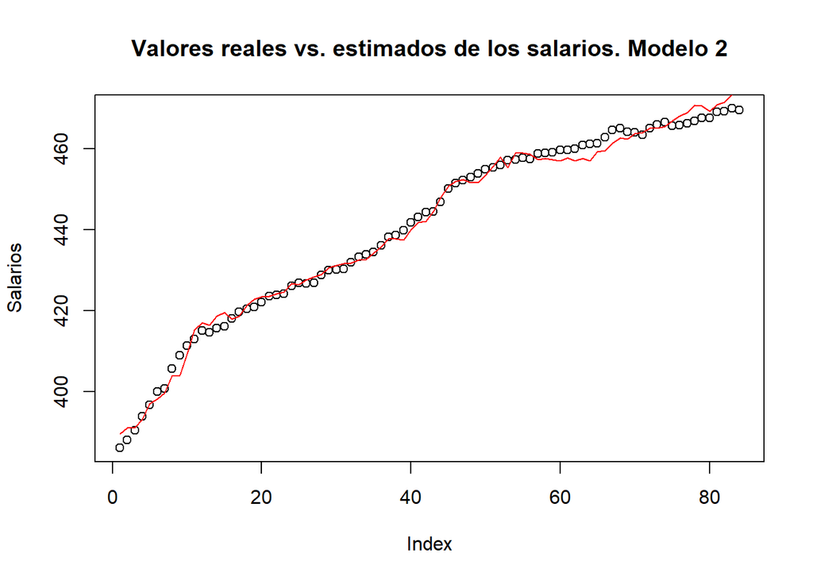

```r
plot(Canada$rw, main = "Valores reales vs. estimados de los salarios. Modelo 2", ylab = "Salarios")
lines(mod.multiple2$fitted.values, col = "red")
```

Utilizaría este modelo en lugar del que incluye la productividad, ya que obtenemos un ajuste muy alto del 99% ($R^2 = 0.9926$) y se resolverían los problemas de multicolinealidad y heterocedasticidad, aunque seguiríamos teniendo autocorrelación en los residuos, lo cuál habría que solventar.

## Ejercicio 4

**Con la sintaxis rep(1:4, 84/4) cree una variable cualitativa, que identifique cada trimestre del año. Evalúe la capacidad explicativa del factor trimestre en el empleo.**

```r
Canada$trim <- as.factor(rep(1:4, 84/4))
str(Canada)
```

```
## 'data.frame':    84 obs. of  5 variables:
##  $ e   : num  930 930 930 931 933 ...
##  $ prod: num  405 405 404 404 405 ...
##  $ rw  : num  386 388 391 394 397 ...
##  $ U   : num  7.53 7.7 7.47 7.27 7.37 ...
##  $ trim: Factor w/ 4 levels "1","2","3","4": 1 2 3 4 1 2 3 4 1 2 ...
```

```r
#Modelo ANOVA
mod.anova <- lm(e~trim, data = Canada)
aov(mod.anova)
```

```
## Call:
##    aov(formula = mod.anova)
##
## Terms:
##                     trim Residuals
## Sum of Squares    15.222  6945.471
## Deg. of Freedom        3        80
##
## Residual standard error: 9.317639
## Estimated effects may be unbalanced
```

```r
summary(mod.anova)
```

```
##
## Call:
## lm(formula = e ~ trim, data = Canada)
##
## Residuals:
##     Min      1Q  Median      3Q     Max
## -16.262  -8.622   1.804   5.817  16.941
##
## Coefficients:
##             Estimate Std. Error t value Pr(>|t|)
## (Intercept) 943.6815     2.0333 464.119   <2e-16 ***
## trim2         0.3917     2.8755   0.136    0.892
## trim3         0.7677     2.8755   0.267    0.790
## trim4         1.1438     2.8755   0.398    0.692
## ---
## Signif. codes:  0 '***' 0.001 '**' 0.01 '*' 0.05 '.' 0.1 ' ' 1
##
## Residual standard error: 9.318 on 80 degrees of freedom
## Multiple R-squared:  0.002187,   Adjusted R-squared:  -0.03523
## F-statistic: 0.05844 on 3 and 80 DF,  p-value: 0.9813
```

El factor trimestre no tiene capacidad explicativa sobre el empleo, ya que el $R^2$ del modelo es extremedamente bajo, y vemos que prácticamente no hay diferencia entre las medias de los distintos factores (los coeficientes son 0.39, 0.76 y 1.14) respecto al factor de referencia (trim1).

Podemos comprobar la igualdad de medias en la siguiente tabla:

```r
model.tables(aov(mod.anova), type = "means")
```

```
## Tables of means
## Grand mean
##
## 944.2573
##
##  trim
## trim
##     1     2     3     4
## 943.7 944.1 944.4 944.8
```

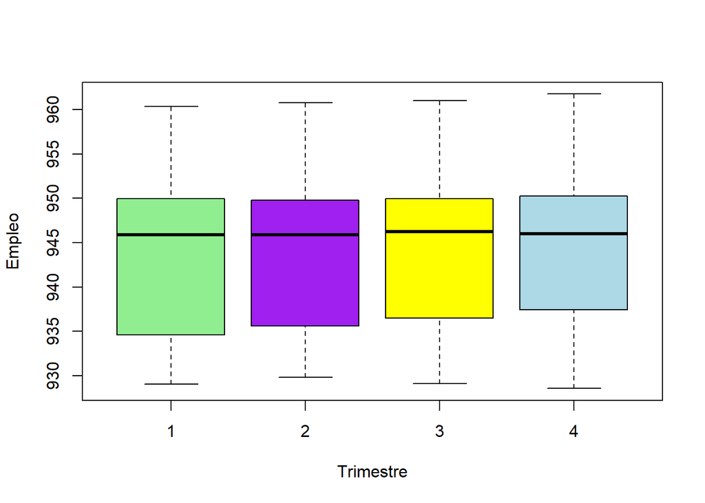

```r
boxplot(Canada$e~Canada$trim, xlab = "Trimestre", ylab = "Empleo", col = c("lightgreen", "purple", "yellow", "lightblue"))
```

## Ejercicio 5

**Con las variables elegidas en el punto anterior, elija el modelo glm más adecuado utilizando las familias Gamma y Gaussiana. Obtenga para los dos modelos: el AIC, el BIC, el estadístico G2 de Wilks, la Chi Cuadrado de Pearson, la prueba de Hosmer‐Lemeshaw, el R2 y el pesudo R2 de McFadden, pesudo R2 de Cox‐Snell y pesudo R2 de Naguelkerke. A la vista de estos estadísticos responda razonadamente cuál de los dos modelos tiene mayor significación. Justifique su elección, y evalúe sus resultados.**

```r
mod.gauss <- glm(rw~e+U, data = Canada, family = gaussian(link = "identity"))
summary(mod.gauss)
```

```
##
## Call:
## glm(formula = rw ~ e + U, family = gaussian(link = "identity"),
##     data = Canada)
##
## Deviance Residuals:
##    Min      1Q  Median      3Q     Max
## -5.612  -1.300  -0.028   1.430   4.938
##
## Coefficients:
##               Estimate Std. Error t value Pr(>|t|)
## (Intercept) -2.243e+03  2.585e+01  -86.76   <2e-16 ***
## e            2.784e+00  2.671e-02  104.24   <2e-16 ***
## U            5.812e+00  1.522e-01   38.19   <2e-16 ***
## ---
## Signif. codes:  0 '***' 0.001 '**' 0.01 '*' 0.05 '.' 0.1 ' ' 1
##
## (Dispersion parameter for gaussian family taken to be 4.091348)
##
##     Null deviance: 44945.8  on 83  degrees of freedom
## Residual deviance:   331.4  on 81  degrees of freedom
## AIC: 361.67
##
## Number of Fisher Scoring iterations: 2
```

```r
mod.gamma <- glm(rw~e+U, data = Canada, family = Gamma(link = "identity"))
summary(mod.gamma)
```

```
##
## Call:
## glm(formula = rw ~ e + U, family = Gamma(link = "identity"),
##     data = Canada)
##
## Deviance Residuals:
##        Min          1Q      Median          3Q         Max
## -0.0122717  -0.0028669  -0.0002262   0.0032166   0.0123103
##
## Coefficients:
##               Estimate Std. Error t value Pr(>|t|)
## (Intercept) -2.248e+03  2.484e+01  -90.51   <2e-16 ***
## e            2.791e+00  2.575e-02  108.37   <2e-16 ***
## U            5.776e+00  1.462e-01   39.52   <2e-16 ***
## ---
## Signif. codes:  0 '***' 0.001 '**' 0.01 '*' 0.05 '.' 0.1 ' ' 1
##
## (Dispersion parameter for Gamma family taken to be 2.084686e-05)
##
##     Null deviance: 0.236721  on 83  degrees of freedom
## Residual deviance: 0.001689  on 81  degrees of freedom
## AIC: 360.6
##
## Number of Fisher Scoring iterations: 3
```

En ambos modelos utilizamos la función vínculo “Identidad”, debido a que la variable respuesta salarios (rw) es continua y los errores en principio son normales.

Para el modelo Gamma podríamos utilizar la función vínculo “Recíproca”, pero al haber comprobado en el ejercicio 3 que los errores son normales, optamos por la función vínculo “Identidad”.

```r
#AIC
paste("AIC Gaussiano: ", AIC(mod.gauss))
```

```
## [1] "AIC Gaussiano:  361.672254054444"
```

```r
paste("AIC Gamma: ", AIC(mod.gamma))
```

```
## [1] "AIC Gamma:  360.596324499446"
```

```r
#BIC
paste("BIC Gaussiano: ", BIC(mod.gauss))
```

```
## [1] "BIC Gaussiano:  371.395521249817"
```

```r
paste("BIC Gamma: ", BIC(mod.gamma))
```

```
## [1] "BIC Gamma:  370.31959169482"
```

```r
#G2 de Wilks
paste("G2 Gaussiano: ", mod.gauss$deviance)
```

```
## [1] "G2 Gaussiano:  331.399206059383"
```

```r
paste("G2 Gamma: ", mod.gamma$deviance)
```

```
## [1] "G2 Gamma:  0.00168898140532066"
```

```r
pD.Gauss <- 1 - pchisq(deviance(mod.gauss), mod.gauss$df.residual)
pD.Gamma <- 1 - pchisq(deviance(mod.gamma), mod.gamma$df.residual)
paste("G2 Gaussiano p-valor: ", pD.Gauss)
```

```
## [1] "G2 Gaussiano p-valor:  0"
```

```r
paste("G2 Gamma p-valor: ", pD.Gamma)
```

```
## [1] "G2 Gamma p-valor:  1"
```

```r
#Chi Cuadrado de Pearson
chi2.mod.gauss <- sum(residuals(mod.gauss, type = "pearson")^2)
chi2.mod.gamma <- sum(residuals(mod.gamma, type = "pearson")^2)
paste("Chi-cuadrado Gaussiano: ", chi2.mod.gauss)
```

```
## [1] "Chi-cuadrado Gaussiano:  331.399206059383"
```

```r
paste("Chi-cuadrado Gamma: ", chi2.mod.gamma)
```

```
## [1] "Chi-cuadrado Gamma:  0.0016885956617829"
```

```r
pchi.mod.gauss <- 1 - pchisq(chi2.mod.gauss, mod.gauss$df.residual)
pchi.mod.gamma <- 1 - pchisq(chi2.mod.gamma, mod.gamma$df.residual)
paste("Chi-cuadrado Gaussiano p-valor: ", pchi.mod.gauss)
```

```
## [1] "Chi-cuadrado Gaussiano p-valor:  0"
```

```r
paste("Chi-cuadrado Gamma p-valor: ", pchi.mod.gamma)
```

```
## [1] "Chi-cuadrado Gamma p-valor:  1"
```

```r
#Hosmer-Lemeshaw
suppressWarnings(suppressPackageStartupMessages(library(ResourceSelection)))
hl.mod.gauss <- hoslem.test(mod.gauss$y, fitted(mod.gauss), g=10)
hl.mod.gamma <- hoslem.test(mod.gamma$y, fitted(mod.gamma), g=10)
hl.mod.gauss
```

```
##
##  Hosmer and Lemeshow goodness of fit (GOF) test
##
## data:  mod.gauss$y, fitted(mod.gauss)
## X-squared = -0.00072776, df = 8, p-value = 1
```

```r
hl.mod.gamma
```

```
##
##  Hosmer and Lemeshow goodness of fit (GOF) test
##
## data:  mod.gamma$y, fitted(mod.gamma)
## X-squared = -0.00073913, df = 8, p-value = 1
```

```r
#Pseudo R2 de McFadden

estnull.gauss <- glm(Canada$rw~1, data = Canada, gaussian(link = "identity"))
R2MF.mod.gauss <- 1 - logLik(mod.gauss)/logLik(estnull.gauss)

estnull.gamma <- glm(Canada$rw~1, data = Canada, Gamma(link = "identity"))
R2MF.mod.gamma <- 1 - logLik(mod.gamma)/logLik(estnull.gamma)
paste("Pseudo R2 McFadden Gaussiano: ", R2MF.mod.gauss)
```

```
## [1] "Pseudo R2 McFadden Gaussiano:  0.538348914618172"
```

```r
paste("Pseudo R2 McFadden Gamma: ", R2MF.mod.gamma)
```

```
## [1] "Pseudo R2 McFadden Gamma:  0.540786839673123"
```

```r
#Pseudo R2 de Cox-Snell y Nagelkerke
suppressWarnings(suppressPackageStartupMessages(library(rcompanion)))
nagelkerke(mod.gauss, restrictNobs = TRUE)
```

```
## $Models
##
## Model: "glm, rw ~ e + U, gaussian(link = \"identity\"), Canada"
## Null:  "glm, rw ~ 1, gaussian(link = \"identity\"), fit$model"
##
## $Pseudo.R.squared.for.model.vs.null
##                              Pseudo.R.squared
## McFadden                             0.538349
## Cox and Snell (ML)                   0.992627
## Nagelkerke (Cragg and Uhler)         0.992735
##
## $Likelihood.ratio.test
##  Df.diff LogLik.diff  Chisq    p.value
##       -2     -206.22 412.43 2.7658e-90
##
## $Number.of.observations
##
## Model: 84
## Null:  84
##
## $Messages
## [1] "Note: For models fit with REML, these statistics are based on refitting with ML"
##
## $Warnings
## [1] "None"
```

```r
nagelkerke(mod.gamma, restrictNobs = TRUE)
```

```
## $Models
##
## Model: "glm, rw ~ e + U, Gamma(link = \"identity\"), Canada"
## Null:  "glm, rw ~ 1, Gamma(link = \"identity\"), fit$model"
##
## $Pseudo.R.squared.for.model.vs.null
##                              Pseudo.R.squared
## McFadden                             0.540787
## Cox and Snell (ML)                   0.992868
## Nagelkerke (Cragg and Uhler)         0.992975
##
## $Likelihood.ratio.test
##  Df.diff LogLik.diff  Chisq    p.value
##       -2     -207.62 415.23 6.8199e-91
##
## $Number.of.observations
##
## Model: 84
## Null:  84
##
## $Messages
## [1] "Note: For models fit with REML, these statistics are based on refitting with ML"
##
## $Warnings
## [1] "None"
```

Los estadísticos AIC y BIC son prácticamente similares para ambos modelos, siendo ligeramente inferiores para el modelo de familia Gamma. Esto quiere decir que el modelo Gamma tendría un mayor ajuste.

En el **Pseudo R2 de McFadden** se considera que los modelos con valores superiores a 0.4 tienen una excelente calidad de ajuste. Ambos modelos están por encima de 0.4 , siendo ligeramente superior el del modelo Gamma (0.54) respecto al del modelo Gaussiano (0.53).

Los valores obtenidos en el **Pseudo R2 de Cox-Snell** y el **Pseudo R2 de Nagelkerke** son prácticamente iguales para ambos modelos (0.99). En estos casos se considera que el ajuste es bueno si está por encima de 0.6 o 0.7, por lo que, tendrían un muy buen ajuste.

Los siguientes estadísticos se utilizan para medir la bondad de ajuste de modelos binomiales, por lo que no serían adecuados para los modelos Gaussiano y Gamma calculados, ya que la variable respuesta de estos es continua y no binaria.

De todos modos, analizamos cuál sería el ajuste de cada uno de estos modelos según dichos estadísticos, si su aplicación fuese adecuada.

- Obtenemos un **G2 de Wilks** mucho menor para el modelo Gamma, así como un p-valor de 1, por lo que según este estadístico, este sería el modelo más adecuado.
- También obtenemos un **Chi-cuadrado de Pearson** mucho menor para el modelo Gamma, así como un p-valor de 1, por lo que según este estadístico, este sería el modelo más adecuado.
- El test de **Hosmer-Lemeshaw** nos indica que ambos modelos son adecuados (p-valor = 1). En esta prueba se agrupan las probabilidades estimadas (en este caso 10 grupos), se calculan las frecuencias esperadas y se comparan las frecuencias de éxito observadas con las estimadas. El valor de este estadístico es negativo en ambos modelos, ya que como explicamos anteriormente, se utiliza para regresiones logísticas y no para este tipo de modelos.

Viendo los valores de todos los estadísticos cálculados, sobre todo del AIC, el BIC y los pseudo $R^2$, podríamos concluir que el modelo Gamma tiene una significación ligeramente mayor a la del modelo Gaussiano.

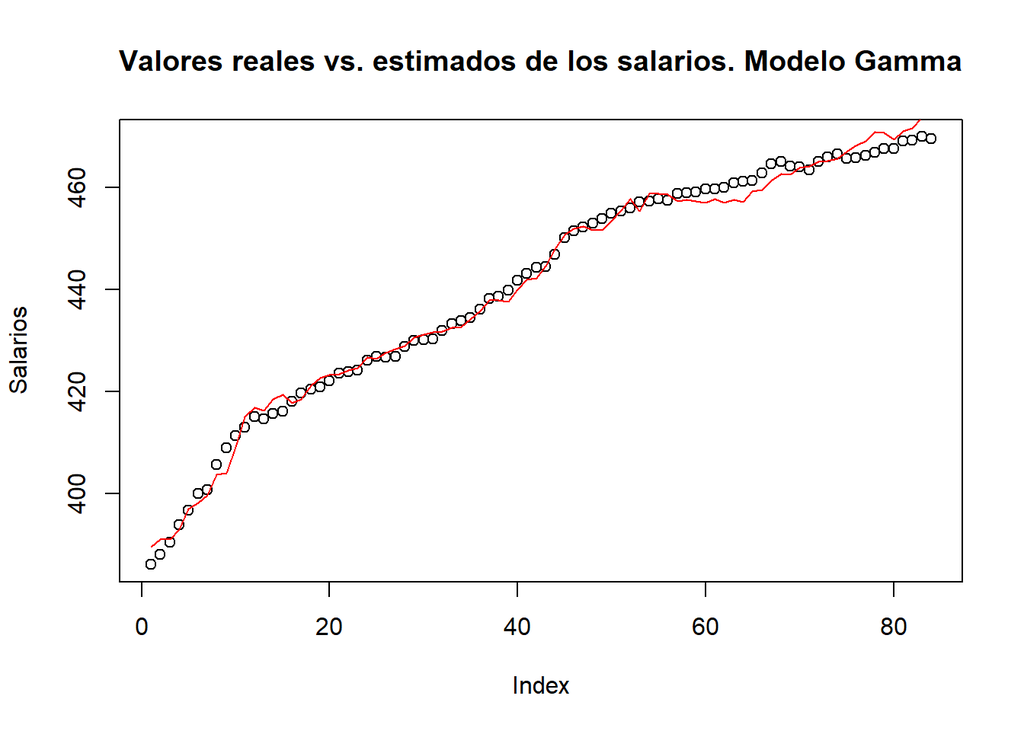

```r
plot(Canada$rw, main = "Valores reales vs. estimados de los salarios. Modelo Gamma", ylab = "Salarios")
lines(mod.gamma$fitted.values, col = "red")
```

También podemos ver en el gráfico que el ajuste del modelo es bueno.

## Ejercicio 6

**Si considera que hay problemas de colinealidad entre los regresores, plantee un modelo que los solucione.**

En el ejercicio 3 se descubría que exisitían problemas de colinealidad entre la variable productividad (prod) y la variable empleo (e). Tras hacer una selección de variables con el método fordward, se descartó la variable productividad resolviendo así dicho problema.

Vamos a plantear un modelo **Ridge** que solucione el problema de multicolinealidad considerando que se hubiese mantenido la variable productividad en el modelo.

La regresión Ridge trata de dar solución a estos problemas de presencia de multicolinealidad, estimando unos parametros “$\beta$ contraidos”. Es decir, sesgo artificialmente las estimaciones para reducir el ECM (Error Cuadrático Medio).

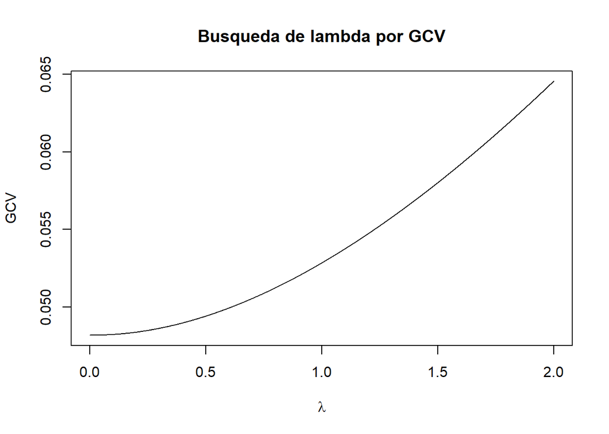

```r
suppressWarnings(suppressPackageStartupMessages(library(broom)))
suppressWarnings(suppressPackageStartupMessages(library(MASS)))
mod.Ridge <- lm.ridge (rw ~ prod + e + U, data = Canada, lambda = seq(0, 2 , .0001))

plot(seq(0, 2, .0001), mod.Ridge$GCV, main ="Busqueda de lambda por GCV", type="l", xlab = expression(lambda), ylab="GCV") #GCV es validación cruzada generalizada
```

```r
g <- glance(mod.Ridge)
sesgo = g$lambdaGCV

mod.Ridgefinal <- lm.ridge(rw ~ prod + e + U, data = Canada, lambda = sesgo)
coef(mod.Ridgefinal)
```

```
##                        prod             e             U
## -2228.9572076    -0.2139763     2.8632622     5.7200838
```

```r
set.seed(1)
#Preparo un conjunto de datos para ver que modelo tiene menor MSPE
suppressWarnings(suppressPackageStartupMessages(library(data.table)))
test<-Canada[sample(84, 30),]#Hago una partición. De los 84 registros de Canadá, obtenme 30 de forma aleatoria

matXtest=data.frame(unos=1, prod=test$prod, e=test$e, U=test$U)
matXtest=as.matrix(matXtest,ncol=4)

coef.ridge = as.vector(coef(mod.Ridgefinal))
coef.ridge = as.matrix(coef.ridge)

pred.lm.test <- predict(mod.multiple2, newdata = test)
pred.ridge.test <- matXtest%*%(coef.ridge)

MSPE.lm.test <- sum((pred.lm.test-test$rw)^2)/nrow(test)
MSPE.ridge.test <- sum((pred.ridge.test-test$rw)^2)/nrow(test)

MSPE.lm.test
```

```
## [1] 2.638463
```

```r
MSPE.ridge.test
```

```
## [1] 2.658306
```

Tras realizar el modelo Ridge y compararlo con el modelo lineal múltiple que no incluye la productividad, vemos que las predicciones son muy similares y que los ECM son prácticamente iguales (2.638 y 2.658), siendo un poco menor para el modelo lineal.

Viendo que no mejora mucho, nos quedaríamos con el modelo más sencillo y con menor ECM, que sería el lineal múltiple sin la variable productividad.

## Ejercicio 7

**Dado que los datos que estamos analizando son indicadores macroeconómicos, en el análisis de datos outlier no se ha considerado la existencia de errores en los datos y tampoco se contempla la posibilidad de prescindir de ninguna observación de cara al análisis. Evalúe si existen o no problemas de observaciones demasiado influyentes en el análisis y establezca la conveniencia o no conveniencia de utilizar técnicas robustas.**

```r
options(scipen = 999)
cooks.distance(mod.gamma)
```

```
##             1             2             3             4             5
## 0.14742856627 0.09736800662 0.00468086913 0.00873892996 0.00125294821
##             6             7             8             9            10
## 0.03243804292 0.00900768765 0.01944795204 0.11976846725 0.02129654102
##            11            12            13            14            15
## 0.03045264844 0.02665192744 0.02161068021 0.05139683722 0.04909095811
##            16            17            18            19            20
## 0.00050965156 0.00542882674 0.00262998690 0.01272130217 0.00464979907
##            21            22            23            24            25
## 0.00006478594 0.00008025284 0.00035671585 0.00067726949 0.00022495975
##            26            27            28            29            30
## 0.00123617391 0.00288923896 0.00003812214 0.00028232295 0.00114706767
##            31            32            33            34            35
## 0.00228018173 0.00005626827 0.00118695323 0.00319127371 0.00013645374
##            36            37            38            39            40
## 0.00015323349 0.00025718608 0.00151883300 0.01478279691 0.00669161710
##            41            42            43            44            45
## 0.00325717244 0.00988151712 0.00002084019 0.00118081677 0.00048962816
##            46            47            48            49            50
## 0.00026776345 0.00005406986 0.00337561409 0.00986166432 0.00484424811
##            51            52            53            54            55
## 0.00008109821 0.01108090031 0.00750674771 0.00820144118 0.00413275697
##            56            57            58            59            60
## 0.00359440913 0.00531228367 0.00368032534 0.00492648809 0.00981925249
##            61            62            63            64            65
## 0.00511716831 0.01252736894 0.01635898382 0.02424181631 0.00675019625
##            66            67            68            69            70
## 0.01717333867 0.01848502673 0.01028018256 0.00513494353 0.00002543281
##            71            72            73            74            75
## 0.00109279191 0.00001555771 0.00130484280 0.00170661354 0.00402152609
##            76            77            78            79            80
## 0.01506447414 0.02168530684 0.04620713849 0.03259903901 0.01247886044
##            81            82            83            84
## 0.01777531421 0.02676550006 0.06135742450 0.15611611369
```

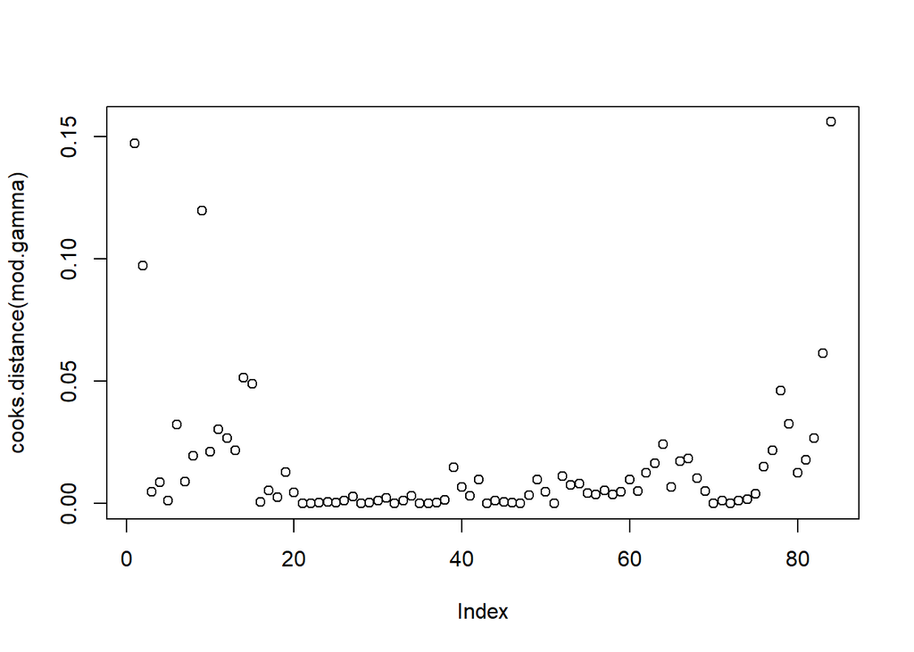

```r
plot(cooks.distance(mod.gamma))
```

Al calcular las **Distancias de Cook** para todas las observaciones del modelo, vemos que en principio no habría problemas de leverage o valores outliers, ya que ninguno tiene un distancia de Cook superior a 1.

De todos modos, vamos a realizar algunos modelos robustos para comprobar si sería conveniente o no su utilización.

```r
#Estimador de Huber
est.huber <- rlm(rw ~ e + U, data = Canada, psi = psi.huber)
summary(est.huber)
```

```
##
## Call: rlm(formula = rw ~ e + U, data = Canada, psi = psi.huber)
## Residuals:
##    Min     1Q Median     3Q    Max
## -5.895 -1.320 -0.147  1.423  5.039
##
## Coefficients:
##             Value      Std. Error t value
## (Intercept) -2252.8668    27.0785   -83.1977
## e               2.7956     0.0280    99.9136
## U               5.7834     0.1594    36.2762
##
## Residual standard error: 2.099 on 81 degrees of freedom
```

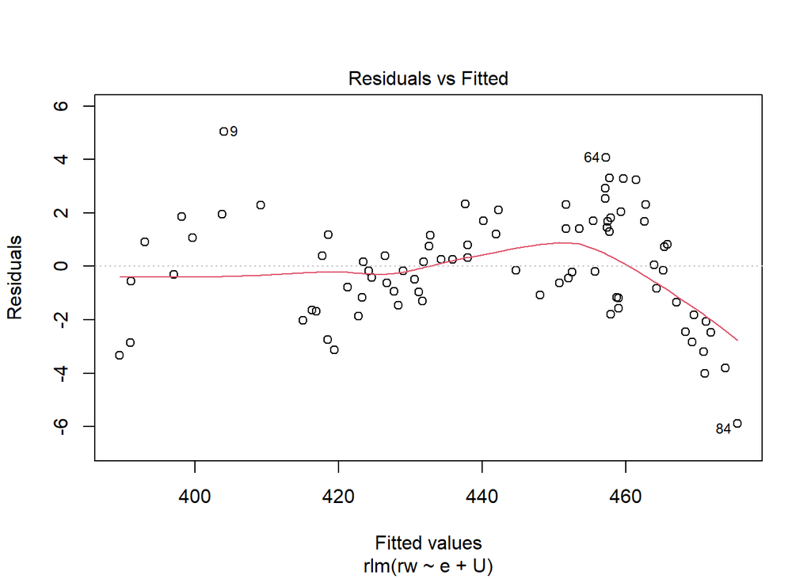

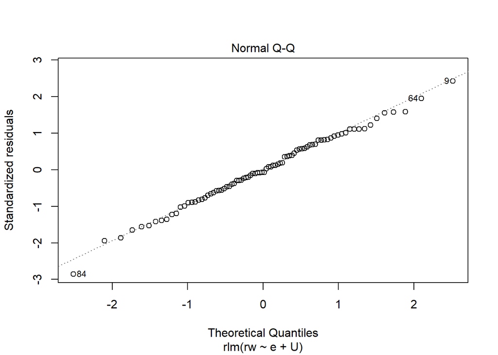

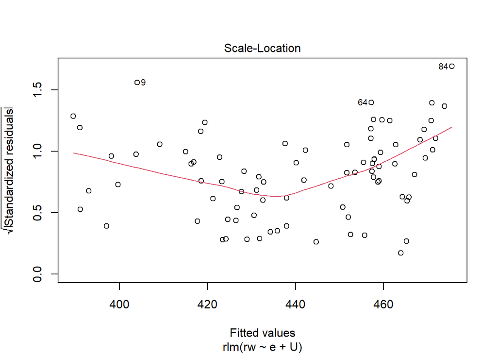

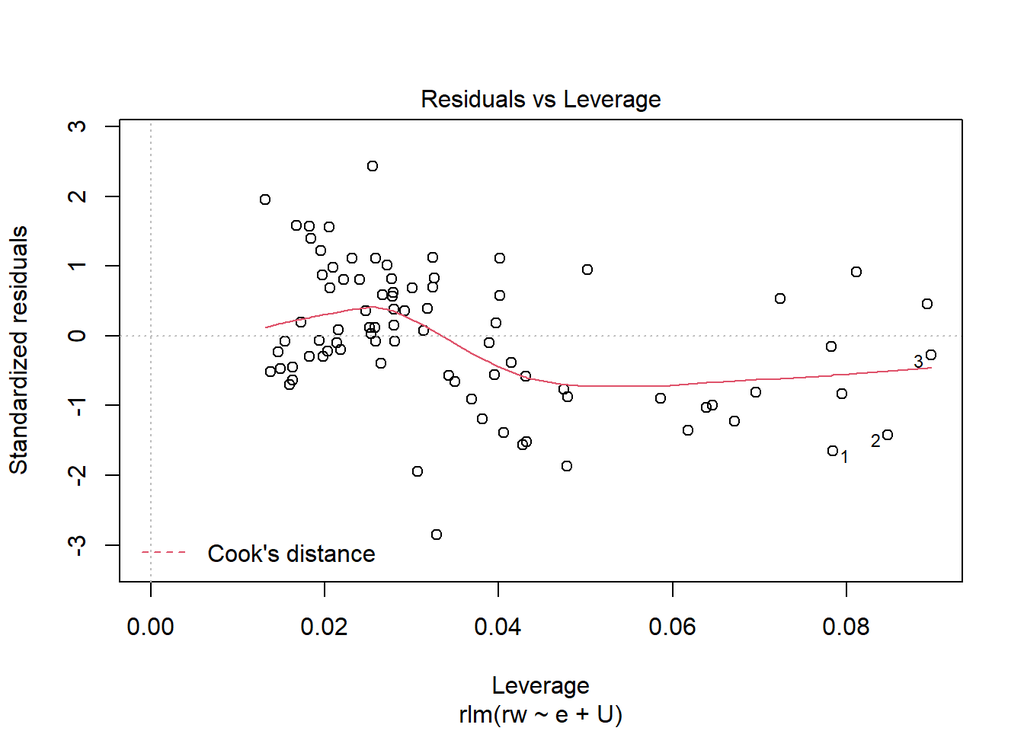

```r
plot(est.huber)
```

```r
#Estimador de Tukey
est.tukey <- rlm(rw ~ e + U, data = Canada, psi = psi.bisquare)
summary(est.tukey)
```

```
##
## Call: rlm(formula = rw ~ e + U, data = Canada, psi = psi.bisquare)
## Residuals:
##     Min      1Q  Median      3Q     Max
## -5.9049 -1.3323 -0.1534  1.4357  5.0119
##
## Coefficients:
##             Value      Std. Error t value
## (Intercept) -2251.5462    26.5280   -84.8744
## e               2.7943     0.0274   101.9401
## U               5.7726     0.1562    36.9598
##
## Residual standard error: 2.115 on 81 degrees of freedom
```

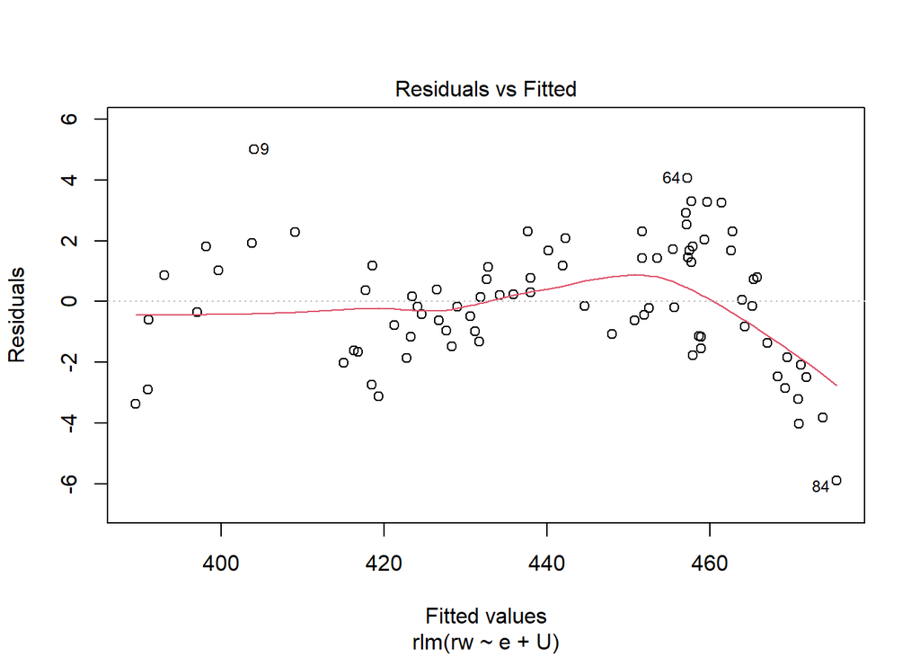

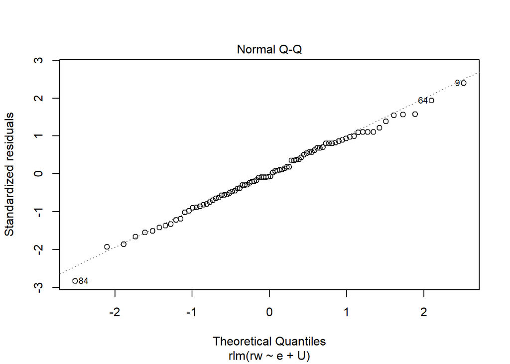

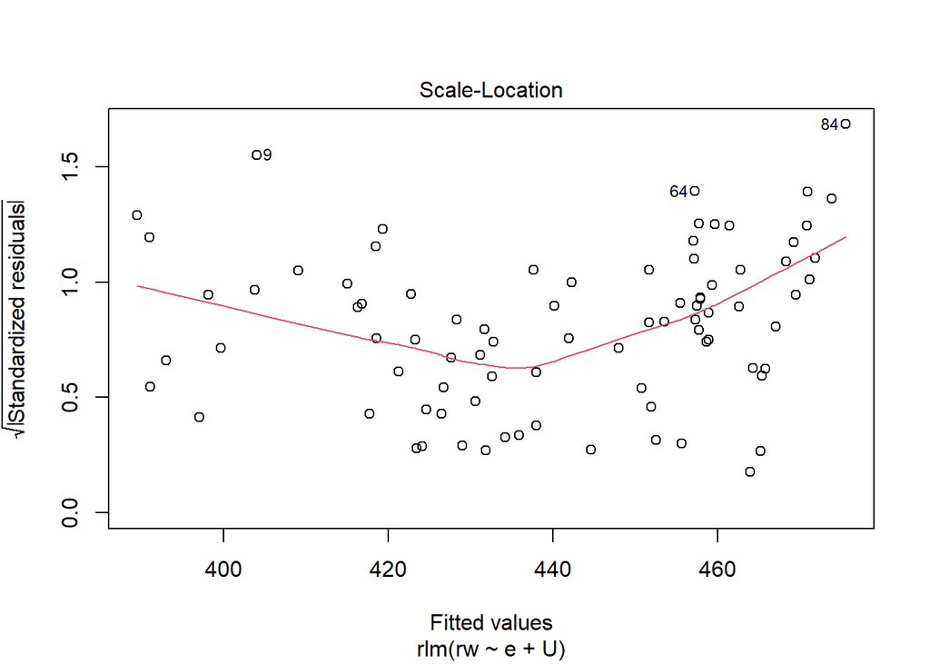

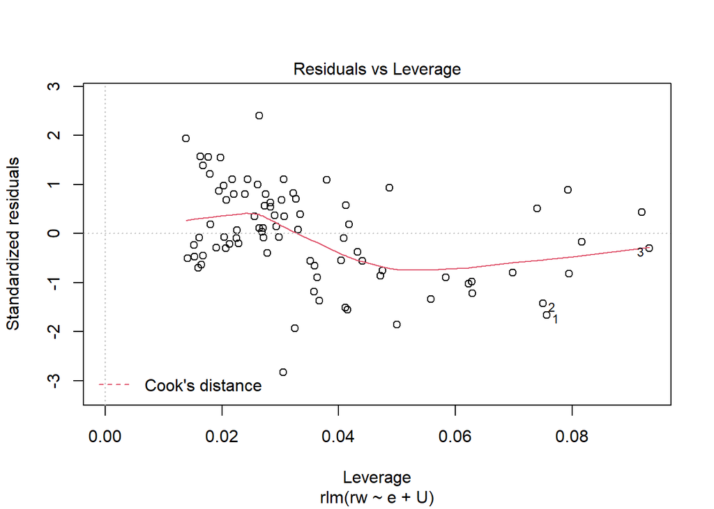

```r
plot(est.tukey)
```

En este caso sería indiferente utilizar un estimador u otro, ya que los errores residuales estándar son casi iguales (Huber: 2.1, Tukey: 2.11).

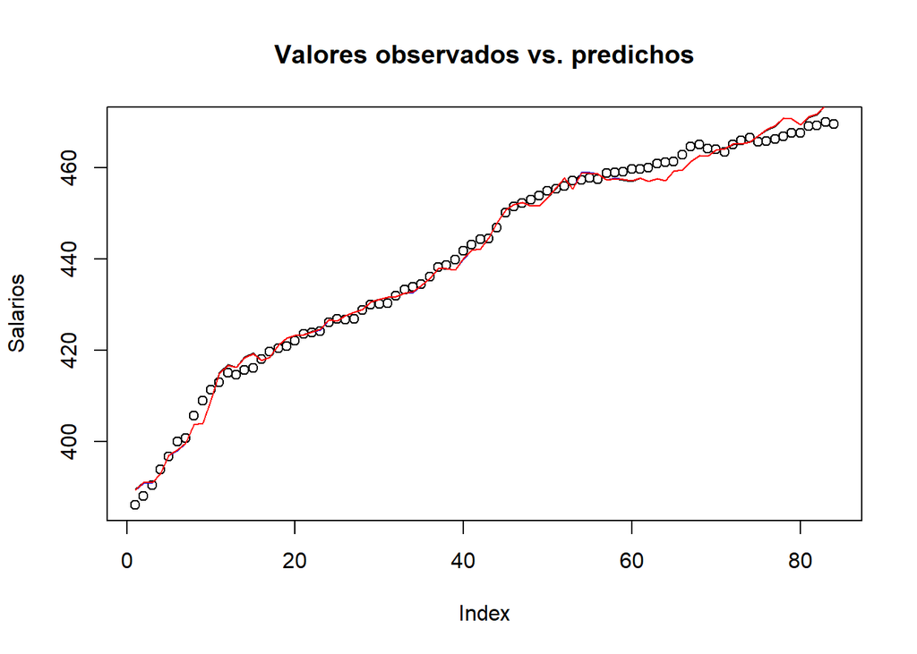

```r
#Gráfico de ajustes
plot(Canada$rw, type = "p", ylab = "Salarios", main = "Valores observados vs. predichos")
lines(mod.gamma$fitted.values, col = "black")
lines(est.huber$fitted.values, col = "blue")
lines(est.tukey$fitted.values, col = "red")
```

```r
paste("AIC Modelo Gamma: ", AIC(mod.gamma))
```

```
## [1] "AIC Modelo Gamma:  360.596324499446"
```

```r
paste("AIC Modelo Huber: ", AIC(est.huber))
```

```
## [1] "AIC Modelo Huber:  362.020736836563"
```

```r
paste("AIC Modelo Tukey: ", AIC(est.tukey))
```

```
## [1] "AIC Modelo Tukey:  362.036800394086"
```

Tanto en el gráfico como con el coeficiente AIC, comprobamos que el ajuste de las estimaciones robustas es muy similar al del modelo MLG.

Por tanto, tal y como indicamos al principio tras comprobar las Distancias de Cook, no sería necesario aplicar técnicas robustas y sería más conveniente utilizar el modelo MLG, ya que tiene un menor AIC.

## Ejercicio 8

**En el ámbito de la psicología diferencial, se ha diseñado un experimento con el objetivo de analizar si existen diferencias en la memoria a corto plazo en función del sexo. Para ello, se seleccionaron al azar 3 mujeres y 3 hombres de la misma edad, subdividiéndolos en 2 grupos experimentales distintos. A cada uno de ellos, se le presentan, sucesivamente y de forma aleatoria, diferentes listas de palabras, registrándose, tras cada presentación, la cantidad de sustantivos y de adjetivos de la lista que recuerda cada sujeto.**

**La siguiente tabla muestra la matriz de datos del experimento, recogiendo la cantidad de palabras recordadas por el sujeto en función de su sexo y de la categoría gramatical a la que pertenece la palabra.**

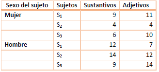

**1) Con los datos que figuran en la tabla genere un data frame almacenando la información obtenida en el experimento.**

```r
datos <- data.frame(
  Sexo = as.factor(c("Mujer", "Mujer", "Mujer", "Hombre", "Hombre", "Hombre")),
  Sujetos = as.factor(c("S1", "S2", "S3", "S4", "S5", "S6")),
  Sustantivos = c(9,4,6,12,14,9),
  Adjetivos = c(11,4,10,7,12,14)
)
str(datos)
```

```
## 'data.frame':    6 obs. of  4 variables:
##  $ Sexo       : Factor w/ 2 levels "Hombre","Mujer": 2 2 2 1 1 1
##  $ Sujetos    : Factor w/ 6 levels "S1","S2","S3",..: 1 2 3 4 5 6
##  $ Sustantivos: num  9 4 6 12 14 9
##  $ Adjetivos  : num  11 4 10 7 12 14
```

```r
suppressWarnings(suppressPackageStartupMessages(library(tidyr)))
datos <- gather(datos, key = "Categoria", value = "Recordadas", 3:4)
datos$Categoria <- as.factor(datos$Categoria)
head(datos)
```

```
##     Sexo Sujetos   Categoria Recordadas
## 1  Mujer      S1 Sustantivos          9
## 2  Mujer      S2 Sustantivos          4
## 3  Mujer      S3 Sustantivos          6
## 4 Hombre      S4 Sustantivos         12
## 5 Hombre      S5 Sustantivos         14
## 6 Hombre      S6 Sustantivos          9
```

**2) Realice un análisis descriptivo del data frame generado, mediante tablas y gráficos.**

```r
summary(datos)
```

```
##      Sexo   Sujetos       Categoria   Recordadas
##  Hombre:6   S1:2    Adjetivos  :6   Min.   : 4.000
##  Mujer :6   S2:2    Sustantivos:6   1st Qu.: 6.750
##             S3:2                    Median : 9.500
##             S4:2                    Mean   : 9.333
##             S5:2                    3rd Qu.:12.000
##             S6:2                    Max.   :14.000
```

Vemos que la media de palabras recordadas es de 9.33, mientras que las mínimas son 4 y las máximas 14.

Comprobamos las medias según los niveles de los factores.

```r
#Según sexo
aggregate(datos$Recordadas, by = list(datos$Sexo), FUN = mean)
```

```
##   Group.1         x
## 1  Hombre 11.333333
## 2   Mujer  7.333333
```

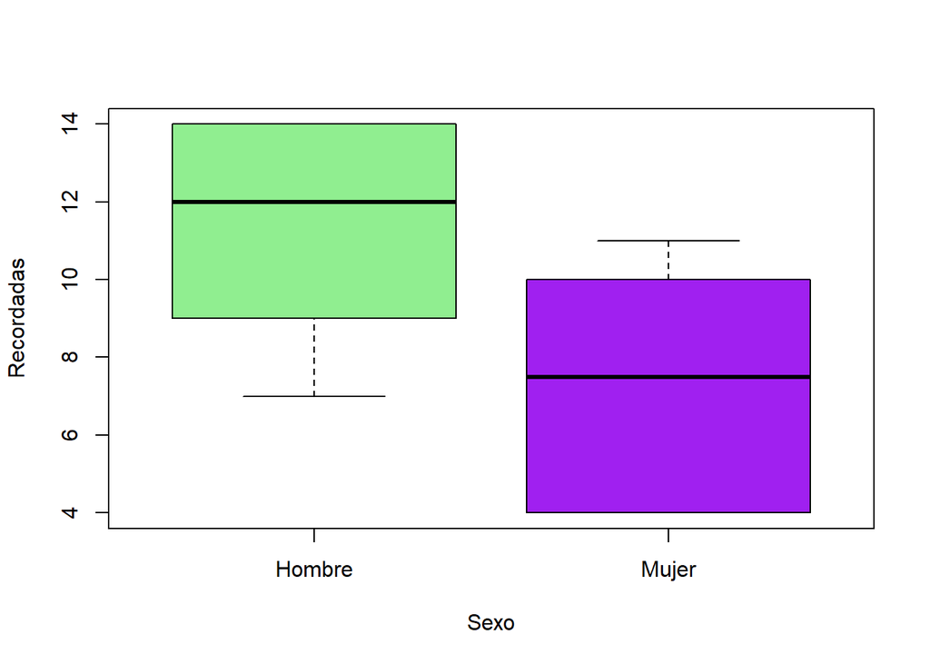

```r
boxplot(Recordadas ~ Sexo, data = datos, col = c("lightgreen","purple"))
```

Los hombres han recordado de media más palabras que las mujeres (11.33 frente a 7.33), independientemente de la categoría gramatical.

```r
#Según categoría gramatical
aggregate(datos$Recordadas, by = list(datos$Categoria), FUN = mean)
```

```
##       Group.1        x
## 1   Adjetivos 9.666667
## 2 Sustantivos 9.000000
```

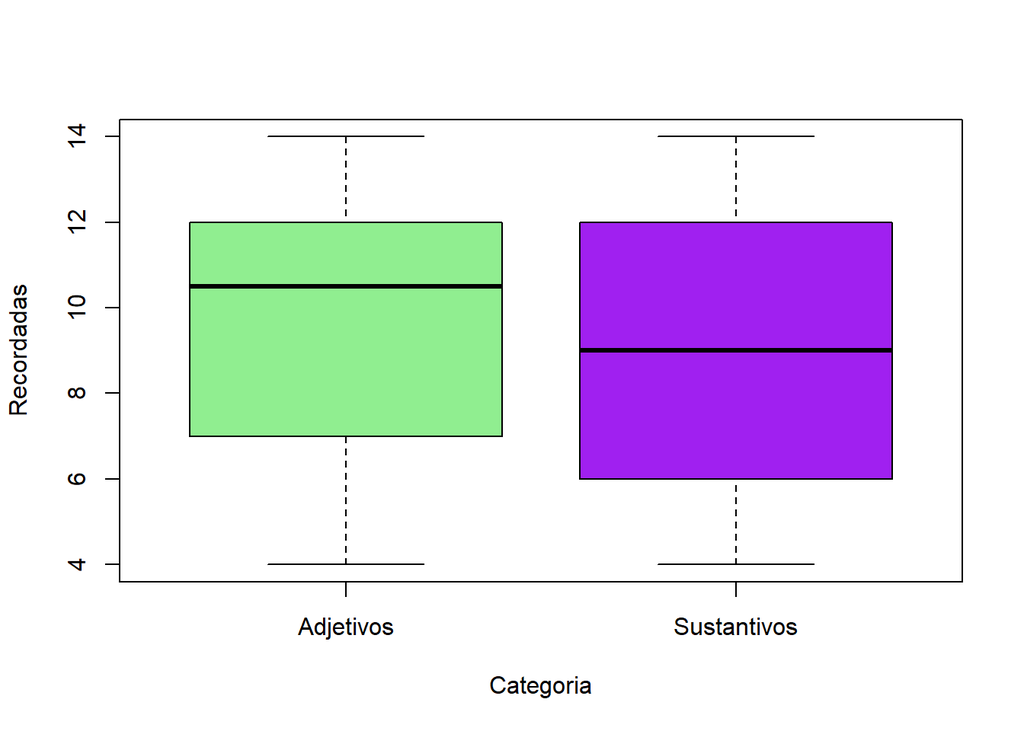

```r
boxplot(Recordadas ~ Categoria, data = datos, col = c("lightgreen", "purple"))
```

La media de palabras recordadas es similar para los adjetivos y sustantivos, siendo un poco mayor para los adjetivos.

```r
#Según sujeto
aggregate(datos$Recordadas, by = list(datos$Sujetos), FUN = mean)
```

```
##   Group.1    x
## 1      S1 10.0
## 2      S2  4.0
## 3      S3  8.0
## 4      S4  9.5
## 5      S5 13.0
## 6      S6 11.5
```

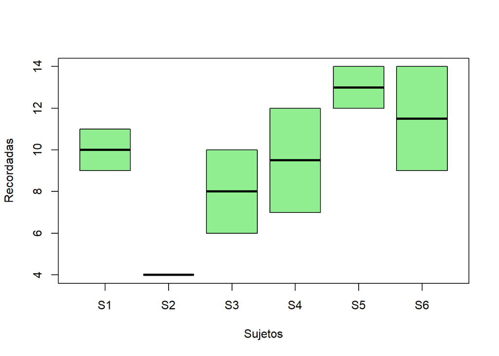

```r
boxplot(Recordadas ~ Sujetos, data = datos, col = ("lightgreen"))
```

El sujeto 5 es el que ha recordado más palabras de media (13), y el sujeto 2 es el que ha recordado menos (4).

```r
#Según Sexo y Categoría
aggregate(datos$Recordadas, by = list (datos$Sexo, datos$Categoria), FUN = mean)
```

```
##   Group.1     Group.2         x
## 1  Hombre   Adjetivos 11.000000
## 2   Mujer   Adjetivos  8.333333
## 3  Hombre Sustantivos 11.666667
## 4   Mujer Sustantivos  6.333333
```

Los hombres han recordado de media prácticamente el mismo número de adjetivos que sustantivos. Las mujeres han recordado de media más adjetivos que sustantivos.

**3) Describa el diseño experimental utilizado, identificando los distintos tipos de variables independientes, y estime el modelo pertinente.**

Se trata de un modelo **Split-Plot** en el que el factor A es el sexo, el factor B es la categoría gramatical y el factor P es el sujeto, siendo los factores A y B fijos y el factor P aleatorio.

Parametrizamos los distintos efectos:

- $μ$ = media general.
- $\alpha_i$ = efecto del nivel i de la variable de clasificación (efecto A = sexo).
- $P_{j(i)}$ = efecto debido al sujeto j del nivel i de α (componente de error entre).
- $\beta_k$ = efecto del nivel k de la variable correspondiente a la categoría gramatical (efecto B = categoría gramatical).
- $(αβ)_{ik}$ = efecto de la interacción del grupo (sexo) i por la categoría gramatical k.
- $(Pβ)_{j(i)k}$ = efecto de la interacción sujetos por categorías gramaticales, para cada valor de A (componente de error intra).
- $u_{ijk}$ = error de medida.

El modelo finalmente construido será el siguiente:

$Y_{ijk}=μ+α_i+P_{j(i)}+β_k+(αβ)_{ik}+(Pβ)_{j(i)k}+u_{ijk}$

```r
suppressWarnings(suppressPackageStartupMessages(library(lme4)))
#Análisis de la varianza del modelo
summary(aov(Recordadas ~ Categoria*Sexo + Error(Sexo/Sujetos), data = datos))
```

```
##
## Error: Sexo
##      Df Sum Sq Mean Sq
## Sexo  1     48      48
##
## Error: Sexo:Sujetos
##           Df Sum Sq Mean Sq F value Pr(>F)
## Residuals  4  49.67   12.42
##
## Error: Within
##                Df Sum Sq Mean Sq F value Pr(>F)
## Categoria       1  1.333   1.333   0.176  0.697
## Categoria:Sexo  1  5.333   5.333   0.703  0.449
## Residuals       4 30.333   7.583
```

```r
#Estimación del modelo

mod.split_plot = lmer(Recordadas ~ 1 + Categoria * Sexo + (1|Sexo:Sujetos), data = datos)
summary(mod.split_plot)
```

```
## Linear mixed model fit by REML ['lmerMod']
## Formula: Recordadas ~ 1 + Categoria * Sexo + (1 | Sexo:Sujetos)
##    Data: datos
##
## REML criterion at convergence: 45.3
##
## Scaled residuals:
##     Min      1Q  Median      3Q     Max
## -1.1934 -0.5301  0.2539  0.5914  1.0658
##
## Random effects:
##  Groups       Name        Variance Std.Dev.
##  Sexo:Sujetos (Intercept) 2.417    1.555
##  Residual                 7.583    2.754
## Number of obs: 12, groups:  Sexo:Sujetos, 6
##
## Fixed effects:
##                                Estimate Std. Error t value
## (Intercept)                     11.0000     1.8257   6.025
## CategoriaSustantivos             0.6667     2.2485   0.296
## SexoMujer                       -2.6667     2.5820  -1.033
## CategoriaSustantivos:SexoMujer  -2.6667     3.1798  -0.839
##
## Correlation of Fixed Effects:
##             (Intr) CtgrSs SexMjr
## CtgrSstntvs -0.616
## SexoMujer   -0.707  0.435
## CtgrSstn:SM  0.435 -0.707 -0.616
```

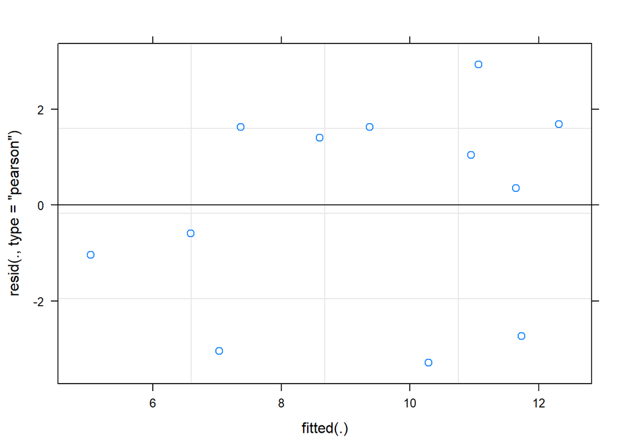

```r
plot(mod.split_plot)
```

**4) En vista de los resultados obtenidos en la descomposición de la variabilidad explicada y no explicada y de los correspondientes tests estadísticos, describa las conclusiones pertinentes.**

El 24,17% de la varianza no explicada es debida al efecto aleatorio correspondiente al sujeto, ya que Sexo:Sujeto = 2.417, y el 75,83% es debida al error experimental. Sería conveniente aumentar la muestra de individuos para reducir el error experimental.

El efecto interacción entre Sexo y Categoría gramatical no es significativo, y tampoco el efecto Sexo (variabilidad explicada). Esto quiere decir que la diferencia de medias entre los efectos fijos Sexo y Categoría gramatical no es significativa.

Por tanto, no podríamos concluir que existan diferencias en la memoria a corto plazo en función del sexo ni en función de la categoría gramatical de las palabras a recordar. Cómo hemos indicado, sería necesario realizar el experimento sobre una muestra mayor para sacar conclusiones claras.